# HW7 Po-Chun Chen N11957611

## Problem 1

You perform an experiment measuring the response of cellular calcium concentration in cell cultures where a certain drug is added at increasing concentrations. The data are in the file “calcium_regression.tsv”.

### Plot the data. What kind of plot is this?

This is a scatter plot. Scatterplot showing metabolite as a function of density

```r
calcium_regression <- read.delim("D:/Desktop/Master_NYU/Statistics in Biology/HW7/calcium_regression.tsv")
str(calcium_regression)
```

```
## 'data.frame':    11 obs. of  2 variables:
##  $ density   : int  0 10 20 30 40 50 60 70 80 90 ...
##  $ metabolite: num  9.45 -13.07 -3.1 -43.6 -38.19 ...
```

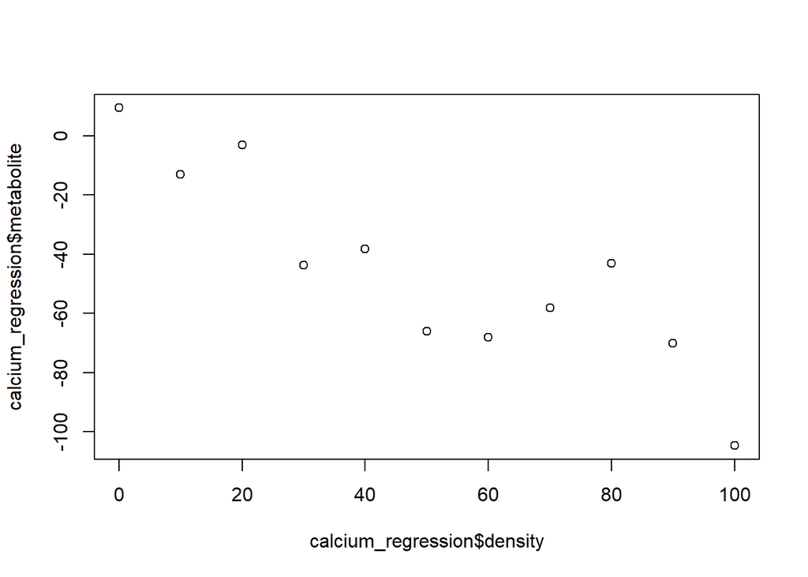

```r
plot(calcium_regression$density,calcium_regression$metabolite)
```

### Perform an appropriate linear regression. What is the best fitting line equation? Show this on the plot, including confidence bands.

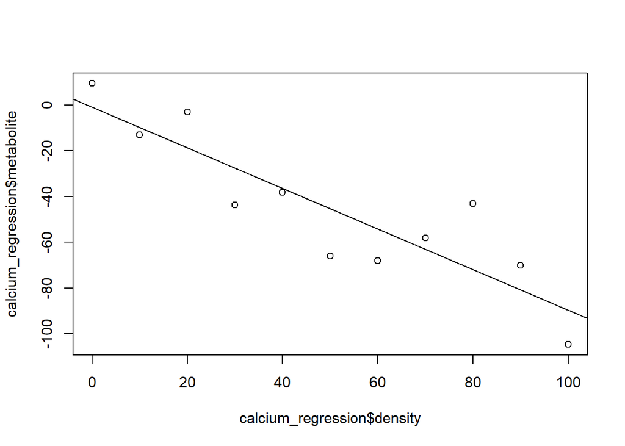

```r
calcium_regression <- read.delim("D:/Desktop/Master_NYU/Statistics in Biology/HW7/calcium_regression.tsv")
plot(calcium_regression$density,calcium_regression$metabolite)
abline(lm(calcium_regression$metabolite~calcium_regression$density))
```

```r
calcium<- lm(calcium_regression$metabolite~calcium_regression$density)
summary.lm(lm(calcium_regression$metabolite~calcium_regression$density))
```

```
##
## Call:
## lm(formula = calcium_regression$metabolite ~ calcium_regression$density)
##
## Residuals:
##     Min      1Q  Median      3Q     Max
## -20.780 -14.413  -1.758  10.575  28.940
##
## Coefficients:
##                            Estimate Std. Error t value Pr(>|t|)
## (Intercept)                 -0.9134     9.3039  -0.098 0.923945
## calcium_regression$density  -0.8879     0.1573  -5.646 0.000315 ***
## ---
## Signif. codes:  0 '***' 0.001 '**' 0.01 '*' 0.05 '.' 0.1 ' ' 1
##
## Residual standard error: 16.49 on 9 degrees of freedom
## Multiple R-squared:  0.7798, Adjusted R-squared:  0.7554
## F-statistic: 31.88 on 1 and 9 DF,  p-value: 0.0003152
```

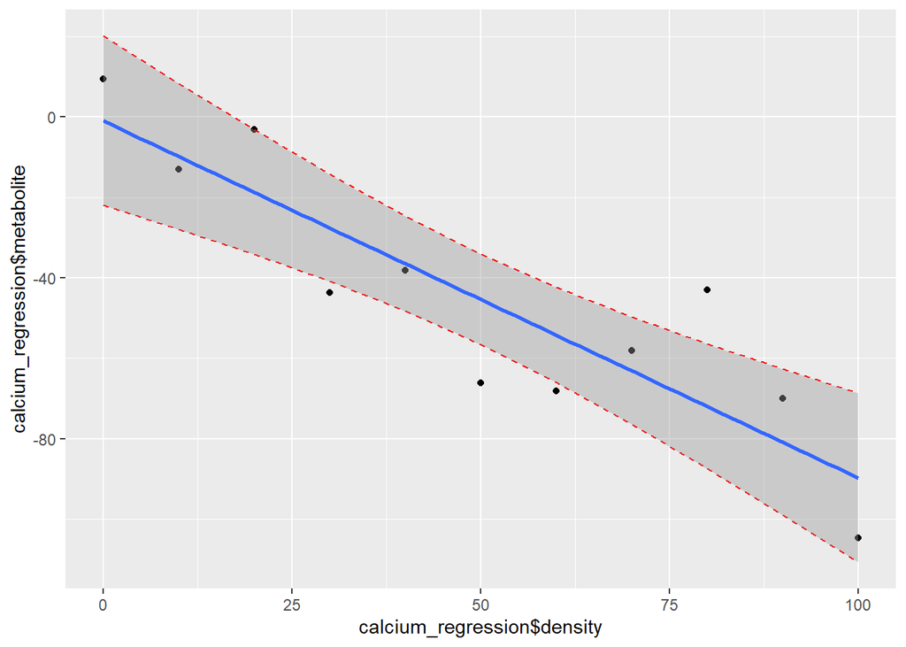

```r
library(ggplot2)
combine<- data.frame(calcium_regression$density,calcium_regression$metabolite)
CI_95 <- predict(calcium, interval="confidence",level=0.95)
new_combine <- cbind(combine, CI_95)
ggplot(new_combine, aes(y = calcium_regression$metabolite, x = calcium_regression$density))+
  geom_point() +
  geom_line(aes(y=lwr), color = "red", linetype = "dashed")+
  geom_line(aes(y=upr), color = "red", linetype = "dashed")+
  geom_smooth(method=lm, se=TRUE)
```

### Check the linear model assumptions using diagnostic plots.

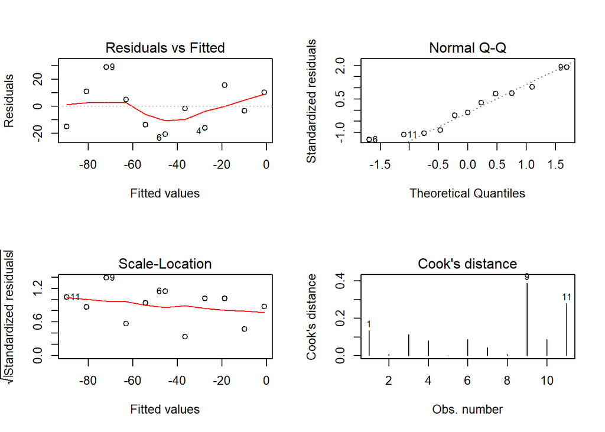

```r
par(mfrow=c(2,2))
plot(calcium,which=1:4)
```

The residuals vs fitted plot is not linear. There seems to be some outliers as well. As for the Normal Q-Q plot, we can say that the data comes from the same distribution as it shows a straight line.

### Hand calculate the (unadjusted) $R^2$ and adjusted $R^2$. Analyse the result of the model fit and report your conclusions.

```r
# Calculate the R squared
calcium_data<- data.frame(calcium_regression, y_hat = fitted(calcium), e = residuals(calcium))
rss <- sum((calcium_data$metabolite-calcium_data$y_hat) ^ 2)  ## residual sum of squares
tss <- sum((calcium_data$metabolite - mean(calcium_data$metabolite)) ^ 2)  ## total sum of squares
rsq <- 1 - rss/tss
rsq
```

```
## [1] 0.7798344
```

```r
# Calculate the adjusted R squared
arsq <- 1- ((1-rsq)*(11-1)/(11-1-1))
arsq
```

```
## [1] 0.7553716
```

R-squared is a statistical measure of how close the data are to the fitted regression line.It is also known as the coefficient of determination

Adjusted r squared is more useful when we have more than 1 independent variables since it adjusts the r square and takes only into consideration the relevant independent variable, which actually explains the variation in the dependent variable. Its value is always less than the R2 value

### Now perform two polynomial regressions, one fitting a quadratic and another fitting a cubic polynomial. Hand calculate the $R^2$ and adjusted $R^2$s and perform similar plots to the above.

```r
calcium.lm2 <- with(calcium_regression, lm(calcium_regression$metabolite ~ calcium_regression$density + I(calcium_regression$density^2)))
summary.lm(calcium.lm2)
```

```
##
## Call:
## lm(formula = calcium_regression$metabolite ~ calcium_regression$density +
##     I(calcium_regression$density^2))
##
## Residuals:
##     Min      1Q  Median      3Q     Max
## -20.987 -11.946   1.882   7.912  29.344
##
## Coefficients:
##                                  Estimate Std. Error t value Pr(>|t|)
## (Intercept)                      5.154376  12.940530   0.398   0.7008
## calcium_regression$density      -1.292449   0.602070  -2.147   0.0641 .
## I(calcium_regression$density^2)  0.004045   0.005799   0.698   0.5052
## ---
## Signif. codes:  0 '***' 0.001 '**' 0.01 '*' 0.05 '.' 0.1 ' ' 1
##
## Residual standard error: 16.99 on 8 degrees of freedom
## Multiple R-squared:  0.7925, Adjusted R-squared:  0.7406
## F-statistic: 15.27 on 2 and 8 DF,  p-value: 0.001855
```

```r
calcium_data2<- data.frame(calcium_regression, y_hat = fitted(calcium.lm2), e = residuals(calcium.lm2))

rss2 <- sum((calcium_data2$metabolite-calcium_data2$y_hat) ^ 2)  ## residual sum of squares
tss2 <- sum((calcium_data2$metabolite - mean(calcium_data2$metabolite)) ^ 2)  ## total sum of squares
rsq2 <- 1 - rss2/tss2
rsq2
```

```
## [1] 0.792459
```

```r
arsq2 <- 1- ((1-rsq2)*(11-1)/(11-2-1))
arsq2
```

```
## [1] 0.7405737
```

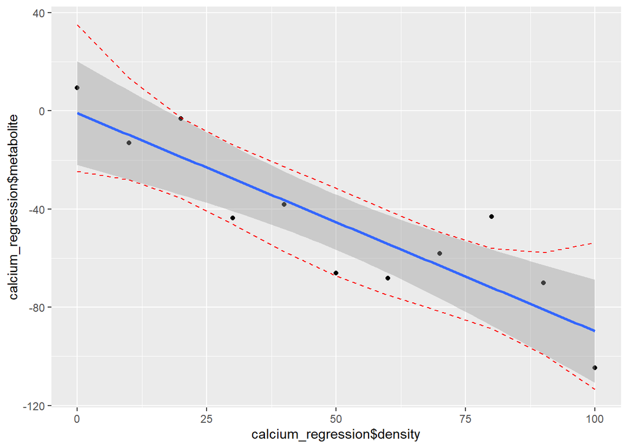

```r
library(ggplot2)
combine2<- data.frame(calcium_regression$density,calcium_regression$metabolite)
CI_952 <- predict(calcium.lm2, interval="confidence",level=0.95)
new_combine2 <- cbind(combine2, CI_952)
ggplot(new_combine2, aes(y = calcium_regression$metabolite, x = calcium_regression$density))+
  geom_point() +
  geom_line(aes(y=lwr), color = "red", linetype = "dashed")+
  geom_line(aes(y=upr), color = "red", linetype = "dashed")+
  geom_smooth(method=lm, se=TRUE)
```

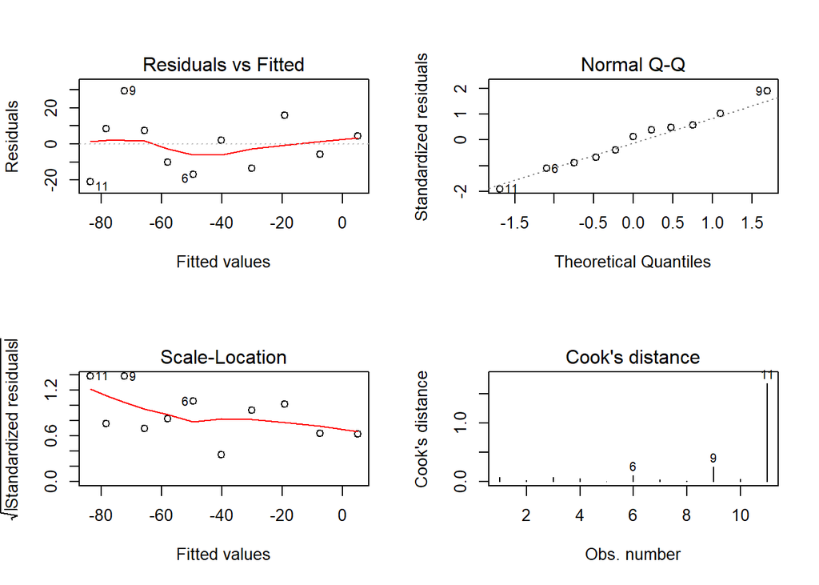

```r
par(mfrow=c(2,2))
plot(calcium.lm2,which=1:4)
```

```r
# Cubic

calcium.lm3 <- with(calcium_regression, lm(calcium_regression$metabolite ~ calcium_regression$density + I(calcium_regression$density^2)+I(calcium_regression$density^3)))
summary.lm(calcium.lm3)
```

```
##
## Call:
## lm(formula = calcium_regression$metabolite ~ calcium_regression$density +
##     I(calcium_regression$density^2) + I(calcium_regression$density^3))
##
## Residuals:
##     Min      1Q  Median      3Q     Max
## -16.735  -8.346  -3.676   6.475  23.422
##
## Coefficients:
##                                  Estimate Std. Error t value Pr(>|t|)
## (Intercept)                     15.307567  14.320700   1.069   0.3206
## calcium_regression$density      -2.905678   1.304078  -2.228   0.0611 .
## I(calcium_regression$density^2)  0.046350   0.031233   1.484   0.1814
## I(calcium_regression$density^3) -0.000282   0.000205  -1.376   0.2112
## ---
## Signif. codes:  0 '***' 0.001 '**' 0.01 '*' 0.05 '.' 0.1 ' ' 1
##
## Residual standard error: 16.11 on 7 degrees of freedom
## Multiple R-squared:  0.8366, Adjusted R-squared:  0.7666
## F-statistic: 11.95 on 3 and 7 DF,  p-value: 0.003832
```

```r
calcium_data3<- data.frame(calcium_regression, y_hat = fitted(calcium.lm3), e = residuals(calcium.lm3))

rss3 <- sum((calcium_data3$metabolite-calcium_data3$y_hat) ^ 2)  ## residual sum of squares
tss3 <- sum((calcium_data3$metabolite - mean(calcium_data3$metabolite)) ^ 2)  ## total sum of squares
rsq3 <- 1 - rss3/tss3
rsq3
```

```
## [1] 0.8366437
```

```r
arsq3 <- 1- ((1-rsq3)*(11-1)/(11-3-1))
arsq3
```

```
## [1] 0.7666338
```

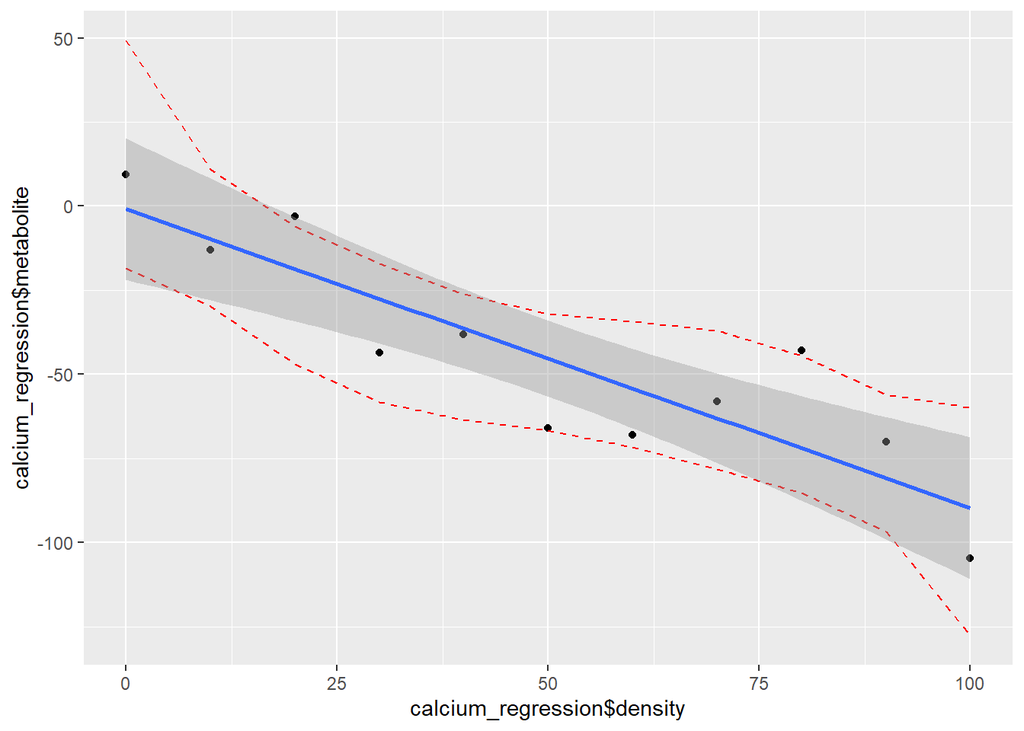

```r
library(ggplot2)
combine3<- data.frame(calcium_regression$density,calcium_regression$metabolite)
CI_953 <- predict(calcium.lm3, interval="confidence",level=0.95)
new_combine3 <- cbind(combine3, CI_953)
ggplot(new_combine3, aes(y = calcium_regression$metabolite, x = calcium_regression$density))+
  geom_point() +
  geom_line(aes(y=lwr), color = "red", linetype = "dashed")+
  geom_line(aes(y=upr), color = "red", linetype = "dashed")+
  geom_smooth(method=lm, se=TRUE)
```

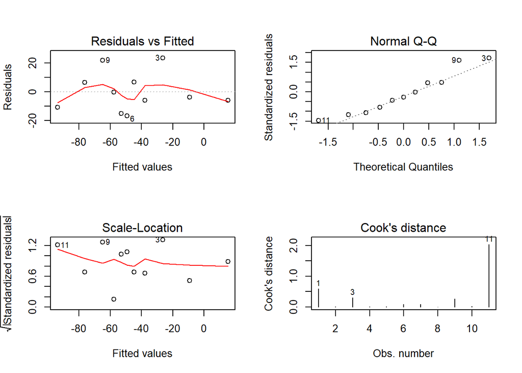

```r
par(mfrow=c(2,2))
plot(calcium.lm3,which=1:4)
```

### Which model fits the best using (i) (unadjusted) $R^2$ and (ii) adjusted $R^2$. Which model do you consider to be the best fit and why?

```r
# Side by Side

require(gridExtra)
```

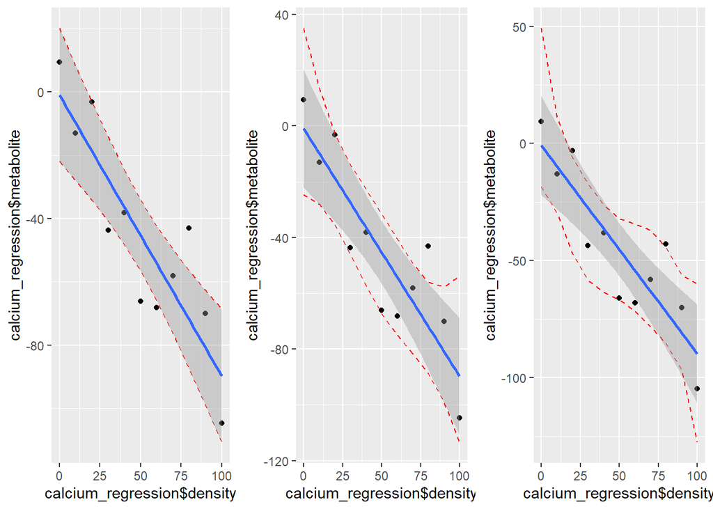

```r
plot1 <- ggplot(new_combine, aes(y = calcium_regression$metabolite, x = calcium_regression$density))+
  geom_point() +
  geom_line(aes(y=lwr), color = "red", linetype = "dashed")+
  geom_line(aes(y=upr), color = "red", linetype = "dashed")+
  geom_smooth(method=lm, se=TRUE)

plot2 <- ggplot(new_combine2, aes(y = calcium_regression$metabolite, x = calcium_regression$density))+
  geom_point() +
  geom_line(aes(y=lwr), color = "red", linetype = "dashed")+
  geom_line(aes(y=upr), color = "red", linetype = "dashed")+
  geom_smooth(method=lm, se=TRUE)

plot3 <- ggplot(new_combine3, aes(y = calcium_regression$metabolite, x = calcium_regression$density))+
  geom_point() +
  geom_line(aes(y=lwr), color = "red", linetype = "dashed")+
  geom_line(aes(y=upr), color = "red", linetype = "dashed")+
  geom_smooth(method=lm, se=TRUE)

grid.arrange(plot1, plot2,plot3, ncol=3)
```

The cubic is the best fit model based on R^2 and adjusted R^2 I would say cubic is a little overfitting. However, it is still the best model in this specific case. Because the dataset is small. We need more data to judge.

## Problem 2

The data are in the asbio data frame wash.rich, which can be loaded into the R workspace with the command data(wash.rich). If you are not able to install the asbio package, you may read in the data frame wash.rich.txt, which is attached to this assignment. The explanatory and response variables are explained in example 9.6. Examine the data with the head() and str() functions. Note that the response variable Y is integer, but Aho is using the idea that Poisson random numbers can be approximated as gaussian for very large Poisson means. The Y integers are not very large here. Nevertheless, let’s go along with Aho, and make believe that the response variable Y is normal.

### (a)

Test a linear model for the response variable Y in terms of all 5 explanatory variables, and report the p-values for all the regression coefficients, not including the intercept. Call the model lm12345, and name various simplified models below in a similar fashion.

```r
library(asbio)
wash.rich <- read.csv("D:/Desktop/Master_NYU/Statistics in Biology/HW7/wash.rich.txt", row.names=1, sep="")
head(wash.rich)
```

```
##      site  Y   X1   X2 X3    X4   X5
## 1  WA1_R1 17 0.29 18.0 22 70.00 7.62
## 2  WA1_R2 19 0.17 18.0 22 47.50 6.70
## 3 WA1_NF1 24 0.58 24.0 63 16.25 7.21
## 4 WA1_NF2 22 0.59 24.0 63  3.75 7.10
## 5 WA1_SM1 23 0.38 19.5 31  5.00 6.48
## 6 WA1_SM2 21 0.39 19.5 31 16.25 5.52
```

```r
str(wash.rich)
```

```
## 'data.frame':    40 obs. of  7 variables:
##  $ site: Factor w/ 40 levels "WA1_L1","WA1_L2",..: 5 6 3 4 9 10 1 2 7 8 ...
##  $ Y   : int  17 19 24 22 23 21 4 3 23 25 ...
##  $ X1  : num  0.29 0.17 0.58 0.59 0.38 0.39 0.06 0.07 0.45 0.47 ...
##  $ X2  : num  18 18 24 24 19.5 19.5 32 31.5 28.5 28.5 ...
##  $ X3  : int  22 22 63 63 31 31 163 178 62 62 ...
##  $ X4  : num  70 47.5 16.25 3.75 5 ...
##  $ X5  : num  7.62 6.7 7.21 7.1 6.48 5.52 6.89 7.15 7.09 6.96 ...
```

```r
wash.rich$X3<-as.numeric(wash.rich$X3)
wash.rich$Y<-as.numeric(wash.rich$Y)
str(wash.rich)
```

```
## 'data.frame':    40 obs. of  7 variables:
##  $ site: Factor w/ 40 levels "WA1_L1","WA1_L2",..: 5 6 3 4 9 10 1 2 7 8 ...
##  $ Y   : num  17 19 24 22 23 21 4 3 23 25 ...
##  $ X1  : num  0.29 0.17 0.58 0.59 0.38 0.39 0.06 0.07 0.45 0.47 ...
##  $ X2  : num  18 18 24 24 19.5 19.5 32 31.5 28.5 28.5 ...
##  $ X3  : num  22 22 63 63 31 31 163 178 62 62 ...
##  $ X4  : num  70 47.5 16.25 3.75 5 ...
##  $ X5  : num  7.62 6.7 7.21 7.1 6.48 5.52 6.89 7.15 7.09 6.96 ...
```

```r
lm12345.lm<-summary.lm(lm(Y~X1+X2+X3+X4+X5, data=wash.rich))
summary.lm(lm(Y~X1+X2+X3+X4+X5, data=wash.rich))
```

```
##
## Call:
## lm(formula = Y ~ X1 + X2 + X3 + X4 + X5, data = wash.rich)
##
## Residuals:
##     Min      1Q  Median      3Q     Max
## -9.3079 -2.5606  0.7016  3.0207  6.2828
##
## Coefficients:
##             Estimate Std. Error t value Pr(>|t|)
## (Intercept) 43.96128    9.49284   4.631 5.14e-05 ***
## X1          -3.75041    5.00804  -0.749 0.459081
## X2           0.02958    0.11063   0.267 0.790828
## X3          -0.02423    0.01882  -1.288 0.206439
## X4          -0.15365    0.03948  -3.892 0.000441 ***
## X5          -2.49368    1.39578  -1.787 0.082925 .
## ---
## Signif. codes:  0 '***' 0.001 '**' 0.01 '*' 0.05 '.' 0.1 ' ' 1
##
## Residual standard error: 4.347 on 34 degrees of freedom
## Multiple R-squared:  0.679,  Adjusted R-squared:  0.6318
## F-statistic: 14.38 on 5 and 34 DF,  p-value: 1.394e-07
```

```r
lm12345.lm$coefficients[2:6,4]
```

```
##           X1           X2           X3           X4           X5
## 0.4590807158 0.7908277590 0.2064386613 0.0004408796 0.0829247152
```

### (b)

Plot residuals versus fitted values for the full model. Does there appear to be any strong evidence (by eye) that the variation in residuals is not uniform across the fitted values?

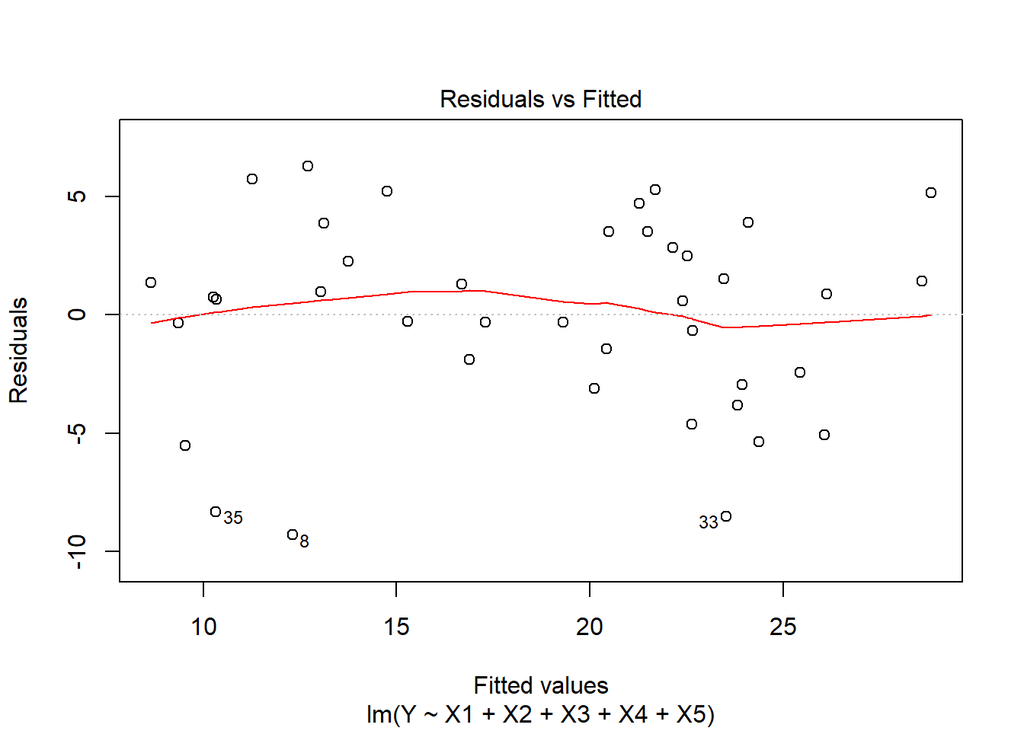

```r
lm12345<-lm(Y~X1+X2+X3+X4+X5, data=wash.rich)
plot(lm12345,which=1)
```

Yes, there are some variation in residuals is not uniform across the fitted values.

### (c)

In a manual, step-wise manner (up to a point), in each round of model simplification, remove the explanatory variable with the highest p-value and report on the p-values of the remaining explanatory variables in the simpler model.

There is a formal way of checking whether the simplification was justified that is based on an F statistic computed form the residuals of the 2 models being compared. The R function is anova(), and the arguments are the 2 model names, with the simpler model first. For example, if one were to compare the full model with the one after removing explanatory variable 3, the command would be anova(lm1245,lm12345). The output includes the p-value for an F statistic for the null hypothesis that there is no difference in the explanatory power between the 2 models. A p-value higher than some cutoff, e.g., 0.01, indicates that the simplification was justified.

Continue the simplification process and check to see if the justification was justified for each round of model simplification, until reaching a point where no further simplification is justified. Report your final model and the p-values of the regression coefficients.

```r
lm12345.lm<-summary.lm(lm(Y~X1+X2+X3+X4+X5, data=wash.rich))
lm12345<-lm(Y~X1+X2+X3+X4+X5, data=wash.rich)
lm12345.lm
```

```
##
## Call:
## lm(formula = Y ~ X1 + X2 + X3 + X4 + X5, data = wash.rich)
##
## Residuals:
##     Min      1Q  Median      3Q     Max
## -9.3079 -2.5606  0.7016  3.0207  6.2828
##
## Coefficients:
##             Estimate Std. Error t value Pr(>|t|)
## (Intercept) 43.96128    9.49284   4.631 5.14e-05 ***
## X1          -3.75041    5.00804  -0.749 0.459081
## X2           0.02958    0.11063   0.267 0.790828
## X3          -0.02423    0.01882  -1.288 0.206439
## X4          -0.15365    0.03948  -3.892 0.000441 ***
## X5          -2.49368    1.39578  -1.787 0.082925 .
## ---
## Signif. codes:  0 '***' 0.001 '**' 0.01 '*' 0.05 '.' 0.1 ' ' 1
##
## Residual standard error: 4.347 on 34 degrees of freedom
## Multiple R-squared:  0.679,  Adjusted R-squared:  0.6318
## F-statistic: 14.38 on 5 and 34 DF,  p-value: 1.394e-07
```

```r
# remove X2

lm1345.lm<-summary.lm(lm(Y~X1+X3+X4+X5, data=wash.rich))
lm1345<-lm(Y~X1+X3+X4+X5, data=wash.rich)
lm1345.lm
```

```
##
## Call:
## lm(formula = Y ~ X1 + X3 + X4 + X5, data = wash.rich)
##
## Residuals:
##     Min      1Q  Median      3Q     Max
## -9.2031 -2.5743  0.8103  3.0641  5.9199
##
## Coefficients:
##             Estimate Std. Error t value Pr(>|t|)
## (Intercept) 44.53311    9.12520   4.880  2.3e-05 ***
## X1          -4.21218    4.63795  -0.908 0.369985
## X3          -0.02361    0.01842  -1.282 0.208373
## X4          -0.15322    0.03892  -3.937 0.000375 ***
## X5          -2.47298    1.37502  -1.799 0.080726 .
## ---
## Signif. codes:  0 '***' 0.001 '**' 0.01 '*' 0.05 '.' 0.1 ' ' 1
##
## Residual standard error: 4.289 on 35 degrees of freedom
## Multiple R-squared:  0.6783, Adjusted R-squared:  0.6415
## F-statistic: 18.45 on 4 and 35 DF,  p-value: 3.091e-08
```

```r
anova(lm1345,lm12345)
```

```
## Analysis of Variance Table
##
## Model 1: Y ~ X1 + X3 + X4 + X5
## Model 2: Y ~ X1 + X2 + X3 + X4 + X5
##   Res.Df    RSS Df Sum of Sq      F Pr(>F)
## 1     35 643.73
## 2     34 642.38  1    1.3503 0.0715 0.7908
```

```r
# remove X1

lm345.lm<-summary.lm(lm(Y~X3+X4+X5, data=wash.rich))
lm345<-lm(Y~X3+X4+X5, data=wash.rich)
lm345.lm
```

```
##
## Call:
## lm(formula = Y ~ X3 + X4 + X5, data = wash.rich)
##
## Residuals:
##     Min      1Q  Median      3Q     Max
## -10.372  -2.678   0.759   2.865   6.042
##
## Coefficients:
##             Estimate Std. Error t value Pr(>|t|)
## (Intercept) 41.51544    8.47806   4.897 2.06e-05 ***
## X3          -0.02371    0.01837  -1.290   0.2052
## X4          -0.12924    0.02852  -4.531 6.23e-05 ***
## X5          -2.40487    1.36963  -1.756   0.0876 .
## ---
## Signif. codes:  0 '***' 0.001 '**' 0.01 '*' 0.05 '.' 0.1 ' ' 1
##
## Residual standard error: 4.278 on 36 degrees of freedom
## Multiple R-squared:  0.6707, Adjusted R-squared:  0.6433
## F-statistic: 24.44 on 3 and 36 DF,  p-value: 8.397e-09
```

```r
anova(lm345,lm1345)
```

```
## Analysis of Variance Table
##
## Model 1: Y ~ X3 + X4 + X5
## Model 2: Y ~ X1 + X3 + X4 + X5
##   Res.Df    RSS Df Sum of Sq      F Pr(>F)
## 1     36 658.90
## 2     35 643.73  1     15.17 0.8248   0.37
```

```r
# remove X3

lm45.lm<-summary.lm(lm(Y~X4+X5, data=wash.rich))
lm45<-lm(Y~X4+X5, data=wash.rich)
lm45.lm
```

```
##
## Call:
## lm(formula = Y ~ X4 + X5, data = wash.rich)
##
## Residuals:
##     Min      1Q  Median      3Q     Max
## -9.9239 -2.8804  0.9256  2.7386  6.5116
##
## Coefficients:
##             Estimate Std. Error t value Pr(>|t|)
## (Intercept) 42.22065    8.53609   4.946 1.67e-05 ***
## X4          -0.15225    0.02246  -6.779 5.59e-08 ***
## X5          -2.68674    1.36419  -1.969   0.0564 .
## ---
## Signif. codes:  0 '***' 0.001 '**' 0.01 '*' 0.05 '.' 0.1 ' ' 1
##
## Residual standard error: 4.316 on 37 degrees of freedom
## Multiple R-squared:  0.6555, Adjusted R-squared:  0.6369
## F-statistic:  35.2 on 2 and 37 DF,  p-value: 2.744e-09
```

```r
anova(lm45,lm345)
```

```
## Analysis of Variance Table
##
## Model 1: Y ~ X4 + X5
## Model 2: Y ~ X3 + X4 + X5
##   Res.Df    RSS Df Sum of Sq      F Pr(>F)
## 1     37 689.37
## 2     36 658.90  1     30.47 1.6648 0.2052
```

```r
# remove X5

lm4.lm<-summary.lm(lm(Y~X4, data=wash.rich))
lm4<-lm(Y~X4, data=wash.rich)
lm4.lm
```

```
##
## Call:
## lm(formula = Y ~ X4, data = wash.rich)
##
## Residuals:
##      Min       1Q   Median       3Q      Max
## -11.3337  -2.8514   0.5514   2.5095   9.3032
##
## Coefficients:
##             Estimate Std. Error t value Pr(>|t|)
## (Intercept) 25.54272    1.11436  22.921  < 2e-16 ***
## X4          -0.16919    0.02152  -7.863 1.72e-09 ***
## ---
## Signif. codes:  0 '***' 0.001 '**' 0.01 '*' 0.05 '.' 0.1 ' ' 1
##
## Residual standard error: 4.477 on 38 degrees of freedom
## Multiple R-squared:  0.6194, Adjusted R-squared:  0.6094
## F-statistic: 61.83 on 1 and 38 DF,  p-value: 1.723e-09
```

```r
anova(lm4,lm45)
```

```
## Analysis of Variance Table
##
## Model 1: Y ~ X4
## Model 2: Y ~ X4 + X5
##   Res.Df    RSS Df Sum of Sq      F  Pr(>F)
## 1     38 761.64
## 2     37 689.37  1    72.269 3.8788 0.05642 .
## ---
## Signif. codes:  0 '***' 0.001 '**' 0.01 '*' 0.05 '.' 0.1 ' ' 1
```

```r
# Final model
summary.lm(lm4)
```

```
##
## Call:
## lm(formula = Y ~ X4, data = wash.rich)
##
## Residuals:
##      Min       1Q   Median       3Q      Max
## -11.3337  -2.8514   0.5514   2.5095   9.3032
##
## Coefficients:
##             Estimate Std. Error t value Pr(>|t|)
## (Intercept) 25.54272    1.11436  22.921  < 2e-16 ***
## X4          -0.16919    0.02152  -7.863 1.72e-09 ***
## ---
## Signif. codes:  0 '***' 0.001 '**' 0.01 '*' 0.05 '.' 0.1 ' ' 1
##
## Residual standard error: 4.477 on 38 degrees of freedom
## Multiple R-squared:  0.6194, Adjusted R-squared:  0.6094
## F-statistic: 61.83 on 1 and 38 DF,  p-value: 1.723e-09
```

### (d)

Use R’s step() function (AIC method) in the backward direction (as in class slides), with the trace parameter set to 1, to simplify the full model automatically. Report on the model that this method finds to be the best, and the p-value(s) of the regression coefficient(s). Is this model the same one you got using the p-value simplification method?

```r
library(MASS)
step <- stepAIC(lm12345, direction="backward")
```

```
## Start:  AIC=123.05
## Y ~ X1 + X2 + X3 + X4 + X5
##
##        Df Sum of Sq    RSS    AIC
## - X2    1     1.350 643.73 121.14
## - X1    1    10.596 652.97 121.71
## - X3    1    31.344 673.72 122.96
## <none>              642.38 123.05
## - X5    1    60.306 702.68 124.64
## - X4    1   286.184 928.56 135.79
##
## Step:  AIC=121.14
## Y ~ X1 + X3 + X4 + X5
##
##        Df Sum of Sq    RSS    AIC
## - X1    1    15.170 658.90 120.07
## - X3    1    30.214 673.94 120.97
## <none>              643.73 121.14
## - X5    1    59.492 703.22 122.67
## - X4    1   285.068 928.79 133.80
##
## Step:  AIC=120.07
## Y ~ X3 + X4 + X5
##
##        Df Sum of Sq     RSS    AIC
## - X3    1     30.47  689.37 119.88
## <none>               658.90 120.07
## - X5    1     56.43  715.32 121.35
## - X4    1    375.82 1034.72 136.12
##
## Step:  AIC=119.88
## Y ~ X4 + X5
##
##        Df Sum of Sq     RSS    AIC
## <none>               689.37 119.88
## - X5    1     72.27  761.64 121.86
## - X4    1    856.28 1545.65 150.17
```

```r
step$anova
```

```
## Stepwise Model Path
## Analysis of Deviance Table
##
## Initial Model:
## Y ~ X1 + X2 + X3 + X4 + X5
##
## Final Model:
## Y ~ X4 + X5
##
##
##   Step Df  Deviance Resid. Df Resid. Dev      AIC
## 1                          34   642.3764 123.0518
## 2 - X2  1  1.350255        35   643.7267 121.1358
## 3 - X1  1 15.170306        36   658.8970 120.0675
## 4 - X3  1 30.470364        37   689.3674 119.8758
```

```r
summary.lm(lm45)
```

```
##
## Call:
## lm(formula = Y ~ X4 + X5, data = wash.rich)
##
## Residuals:
##     Min      1Q  Median      3Q     Max
## -9.9239 -2.8804  0.9256  2.7386  6.5116
##
## Coefficients:
##             Estimate Std. Error t value Pr(>|t|)
## (Intercept) 42.22065    8.53609   4.946 1.67e-05 ***
## X4          -0.15225    0.02246  -6.779 5.59e-08 ***
## X5          -2.68674    1.36419  -1.969   0.0564 .
## ---
## Signif. codes:  0 '***' 0.001 '**' 0.01 '*' 0.05 '.' 0.1 ' ' 1
##
## Residual standard error: 4.316 on 37 degrees of freedom
## Multiple R-squared:  0.6555, Adjusted R-squared:  0.6369
## F-statistic:  35.2 on 2 and 37 DF,  p-value: 2.744e-09
```

```r
AIC(lm12345)
```

```
## [1] 238.5669
```

```r
AIC(lm1345)
```

```
## [1] 236.6509
```

```r
AIC(lm345)
```

```
## [1] 235.5826
```

```r
AIC(lm45)
```

```
## [1] 235.3909
```

```r
AIC(lm4)
```

```
## [1] 237.3787
```

Slightly not the same, if we consider the cutoff should less than 0.05. While comparing lm4 and lm45, the X5 gives a p-value of 0.05642 It is not significant if the cutoff is less than 0.05. However, the step function still gives the X5 in the final model. The reason is that the aim of stepAIC is to give you the model with the lowest AIC. The model lm45 indeed has a lower AIC value compared with lm4.